# Exploring udpipe NLP workflows in R

S Voleti

Hi all,

While py’s Spacy is great and all, R has some solid NLP going for it too. Presenting the udpipe package, based on [Stanford’s *Universal Dependency* (ud) Linguistic typology](http://universaldependencies.org/).

Recall the requirements/building blocks expected from an *ideal* NLP workflow:

- 1. Tokenisation
- 2. Parts of speech tagging
- 3. Lemmatisation
- 4. Morphological feature tagging
- 5. Syntactic dependency parsing
- 6. Named entity recognition (NER)
- 7. Extracting word & sentence meaning

UDPipe provides the standard NLP functionalities of tagging, parsing and dependency evaluations - all within R. [5x slower than Spacy but scalability is apparently not a concern due to easy parallelization](http://www.bnosac.be/index.php/blog/75-a-comparison-between-spacy-and-udpipe-for-natural-language-processing-for-r-users).

And it comes pre-packaged with trained models in as many as **52 languages** (including some desi ones). So why, wait, let’s start. First, with the setup code chunk.

### Setup

Here, we (i) install and load required libraries, and (ii) download trained models in different languages that we’ll later invoke and use.

```r
# setup code block
suppressPackageStartupMessages({
if (!require(udpipe)){install.packages("udpipe")}
if (!require(textrank)){install.packages("textrank")}
if (!require(lattice)){install.packages("lattice")}
if (!require(igraph)){install.packages("igraph")}
if (!require(ggraph)){install.packages("ggraph")}
if (!require(wordcloud)){install.packages("wordcloud")}

library(udpipe)
library(textrank)
library(lattice)
library(igraph)
library(ggraph)
library(ggplot2)
library(wordcloud)
library(stringr)
})

# setup working dir
setwd('C:\\Users\\20052\\Dropbox\\teaching related\\CBA teaching\\TABA\\TABA batch 12\\session 4\\');  getwd()
```

```
## [1] "C:/Users/20052/Dropbox/teaching related/CBA teaching/TABA/TABA batch 12/session 4"
```

```r
# Download language models in English, Spanish and Hindi (say). Uncomment or copy from LMS.
#system.time({

#  ud_model_english <- udpipe_download_model(language = "english")  # 3.05 secs
#  ud_model_spanish <- udpipe_download_model(language = "spanish")  #  secs
#  ud_model_hindi <- udpipe_download_model(language = "hindi")  # secs

#   }) # ~ 114 secs, depends on comp & connection speeds.
```

Site where updated language models for udpipe can be downloaded from: https://lindat.mff.cuni.cz/repository/xmlui/handle/11234/1-2998#

### Basic udpipe functionality

To see udpipe’s basic functionality, let’s return to an old favorite - the Nokia dataset.

Plan is to read in the data from my github page, and annotate the corpus displaying udpipe’s tagging and parsing capabilities in the process.

```r
# get data first
require(stringr)
nokia = readLines('https://raw.githubusercontent.com/sudhir-voleti/sample-data-sets/master/text%20analysis%20data/amazon%20nokia%20lumia%20reviews.txt')
nokia  =  str_replace_all(nokia, "<.*?>", "") # get rid of html junk
str(nokia)
```

```
##  chr [1:120] "I have had Samsung phones, where the screens are nice, but the plastic bodies come apart all of the time and fe"| __truncated__ ...
```

```r
# ?udpipe_download_model   # for langu listing and other details

# load english model for annotation from working dir
english_model = udpipe_load_model("./english-ewt-ud-2.4-190531.udpipe")  # file_model only needed

# now annotate text dataset using ud_model above
# system.time({   # ~ depends on corpus size
  x <- udpipe_annotate(english_model, x = nokia) #%>% as.data.frame() %>% head()
  x <- as.data.frame(x)
#   })  # 13.76 secs

# str(x);
  head(x, 4)
```

|  | doc_id | paragraph_id | sentence_id | sentence | token_id | token | lemma | upos | xpos | feats | head_token_id | dep_rel | deps | misc |
| --- | --- | --- | --- | --- | --- | --- | --- | --- | --- | --- | --- | --- | --- | --- |
| 1 | doc1 | 1 | 1 | I have had Samsung phones, where the screens are nice, but the plastic bodies come apart all of the time and feel flimsy. | 1 | I | I | PRON | PRP | Case=Nom\|Number=Sing\|Person=1\|PronType=Prs | 3 | nsubj | NA | NA |
| 2 | doc1 | 1 | 1 | I have had Samsung phones, where the screens are nice, but the plastic bodies come apart all of the time and feel flimsy. | 2 | have | have | AUX | VBP | Mood=Ind\|Tense=Pres\|VerbForm=Fin | 3 | aux | NA | NA |
| 3 | doc1 | 1 | 1 | I have had Samsung phones, where the screens are nice, but the plastic bodies come apart all of the time and feel flimsy. | 3 | had | have | VERB | VBN | Tense=Past\|VerbForm=Part | 0 | root | NA | NA |
| 4 | doc1 | 1 | 1 | I have had Samsung phones, where the screens are nice, but the plastic bodies come apart all of the time and feel flimsy. | 4 | Samsung | Samsung | VERB | VBN | Tense=Past\|VerbForm=Part | 5 | amod | NA | NA |

Let’s examine the annotated doc output in a little more detail. Can you identify the following requirements in the output?

- 1. Tokenisation - colmns 1-3, 5-6 in the annotated doc
- 2. Parts of speech tagging - colms `xpos` and `upos`
- 3. Lemmatisation - colm `lemma`
- 4. Morphological feature tagging - colm `feats`
- 5. Syntactic dependency parsing - colms 11-13 in the annotated doc.

Note we have the standard penn treebank based POSTags in there, under the colm `xpos`. We also have a simpler set of udpipe based POSTags too, in colm `upos`.

A simple explanation for points 2-5 above [can be found here](http://universaldependencies.org/format.html).

Let’s apply the above for some simple ops. Recall chunking from previously? Well, we can again detect and extract phrases by defining patterns of interest. See below.

```r
table(x$xpos)  # std penn treebank based POStags
```

```
##
##    '' -LRB- -RRB-     $     ,     .     :    ``   ADD   AFX    CC    CD
##    60   117   113     6   793   857    34    51     5     3   665   332
##    DT    EX    FW  HYPH    IN    JJ   JJR   JJS    LS    MD   NFP    NN
##  1523    35    13    64  1502  1147    64    40     3   226    26  2429
##   NNP  NNPS   NNS   PDT   POS   PRP  PRP$    RB   RBR   RBS    RP   SYM
##   600    16   643    25    23  1293   224  1174    19    12    70     8
##    TO    UH    VB   VBD   VBG   VBN   VBP   VBZ   WDT    WP   WRB
##   315    39   774   477   250   271   540   616    87    41    76
```

```r
table(x$upos)  # UD based postags
```

```
##
##   ADJ   ADP   ADV   AUX CCONJ   DET  INTJ  NOUN   NUM  PART  PRON PROPN
##  1250  1232  1035  1159   665  1450    38  3022   332   584  1825   617
## PUNCT SCONJ   SYM  VERB     X
##  2109   340    24  1995    24
```

```r
# So what're the most common nouns? verbs?
all_nouns = x %>% subset(., upos %in% "NOUN")
top_nouns = txt_freq(all_nouns$lemma)  # txt_freq() calcs noun freqs in desc order
head(top_nouns, 10)
```

|  | key | freq | freq_pct |
| --- | --- | --- | --- |
| 1 | phone | 418 | 13.8318994 |
| 2 | app | 85 | 2.8127068 |
| 3 | window | 56 | 1.8530774 |
| 4 | time | 40 | 1.3236267 |
| 5 | screen | 29 | 0.9596294 |
| 6 | music | 27 | 0.8934480 |
| 7 | thing | 26 | 0.8603574 |
| 8 | day | 26 | 0.8603574 |
| 9 | user | 24 | 0.7941760 |
| 10 | camera | 23 | 0.7610854 |

```r
all_verbs = x %>% subset(., upos %in% "VERB")
top_verbs = txt_freq(all_verbs$lemma)
head(top_verbs, 10)
```

|  | key | freq | freq_pct |
| --- | --- | --- | --- |
| 1 | have | 177 | 8.872180 |
| 2 | use | 87 | 4.360902 |
| 3 | get | 84 | 4.210526 |
| 4 | work | 61 | 3.057644 |
| 5 | be | 58 | 2.907268 |
| 6 | buy | 38 | 1.904762 |
| 7 | go | 36 | 1.804511 |
| 8 | love | 33 | 1.654135 |
| 9 | come | 32 | 1.604010 |
| 10 | know | 31 | 1.553885 |

Neat, eh? Can we do more? For instance, can we inquire into `collocations` (i.e. repeated n-grams) and `co-occurrences` (i.e., token pairs co-occurring in the same sentence/ paragraph/ document/ etc)?

Why might you want to do this? One reason is keyword identification and extraction from masses of unstructured text.

Let’s see some quick examples below, via inbuilt routines `keywords_collocation()` and `cooccurrence()`.

### Collocations and Cooccurrences

```r
# Collocation (words following one another)
nokia_colloc <- keywords_collocation(x = x,   # try ?keywords_collocation
                              term = "token",
                              group = c("doc_id", "paragraph_id", "sentence_id"),
                              ngram_max = 4)  # 0.42 secs

str(nokia_colloc)
```

```
## 'data.frame':    1167 obs. of  10 variables:
##  $ keyword   : chr  "City Lens" "diagnostic tool" "Wi - Fi" "Cell - Source" ...
##  $ ngram     : num  2 2 3 3 2 2 2 2 2 2 ...
##  $ left      : chr  "City" "diagnostic" "Wi -" "Cell -" ...
##  $ right     : chr  "Lens" "tool" "Fi" "Source" ...
##  $ freq      : int  3 3 3 3 4 4 3 3 3 3 ...
##  $ freq_left : int  3 3 3 3 5 4 3 4 7 5 ...
##  $ freq_right: int  3 3 3 3 4 5 9 7 4 6 ...
##  $ pmi       : num  12.5 12.5 12.4 12.4 11.8 ...
##  $ md        : num  0 0 0 0 -0.322 ...
##  $ lfmd      : num  -12.5 -12.5 -12.4 -12.4 -12.4 ...
```

```r
nokia_colloc %>% head()
```

|  | keyword | ngram | left | right | freq | freq_left | freq_right | pmi | md | lfmd |
| --- | --- | --- | --- | --- | --- | --- | --- | --- | --- | --- |
| 1 | City Lens | 2 | City | Lens | 3 | 3 | 3 | 12.52658 | 0.0000000 | -12.52658 |
| 2 | diagnostic tool | 2 | diagnostic | tool | 3 | 3 | 3 | 12.52658 | 0.0000000 | -12.52658 |
| 3 | Wi - Fi | 3 | Wi - | Fi | 3 | 3 | 3 | 12.44984 | 0.0000000 | -12.44984 |
| 4 | Cell - Source | 3 | Cell - | Source | 3 | 3 | 3 | 12.44984 | 0.0000000 | -12.44984 |
| 5 | Gorilla Glass | 2 | Gorilla | Glass | 4 | 5 | 4 | 11.78962 | -0.3219281 | -12.43347 |
| 6 | wan na | 2 | wan | na | 4 | 4 | 5 | 11.78962 | -0.3219281 | -12.43347 |

```r
# Sentence Co-occurrences for nouns or adj only
nokia_cooc <- cooccurrence(     # try `?cooccurrence` for parm options
              x = subset(x, upos %in% c("NOUN", "ADJ")),
                      term = "lemma",
                      group = c("doc_id", "paragraph_id", "sentence_id"))  # 0.02 secs
# str(nokia_cooc)
head(nokia_cooc)
```

|  | term1 | term2 | cooc |
| --- | --- | --- | --- |
| 1 | great | phone | 56 |
| 2 | phone | window | 55 |
| 3 | app | phone | 42 |
| 4 | day | view | 37 |
| 5 | cell | phone | 35 |
| 6 | contact | phone | 34 |

```r
# general (non-sentence based) Co-occurrences
nokia_cooc_gen <- cooccurrence(x = x$lemma,
                      relevant = x$upos %in% c("NOUN", "ADJ")) # 0.00 secs
# str(nokia_cooc_gen)
head(nokia_cooc_gen)
```

|  | term1 | term2 | cooc |
| --- | --- | --- | --- |
| 1 | window | phone | 28 |
| 2 | cell | phone | 11 |
| 3 | battery | life | 11 |
| 4 | great | phone | 10 |
| 5 | unlocked | phone | 8 |
| 6 | data | plan | 8 |

```r
# Skipgram based Co-occurrences: How frequent do words follow one another within skipgram number of words
nokia_cooc_skipgm <- cooccurrence(x = x$lemma,
                      relevant = x$upos %in% c("NOUN", "ADJ"),
                      skipgram = 4)  # 0.05 secs

# str(nokia_cooc_skipgm)
head(nokia_cooc_skipgm)  # sorted in descending order
```

|  | term1 | term2 | cooc |
| --- | --- | --- | --- |
| 1 | window | phone | 32 |
| 2 | phone | phone | 21 |
| 3 | phone | great | 19 |
| 4 | unlocked | phone | 16 |
| 5 | great | phone | 15 |
| 6 | new | phone | 12 |

Well, its one thing to see things laid out in a table. Quite another to see it *visualized*.

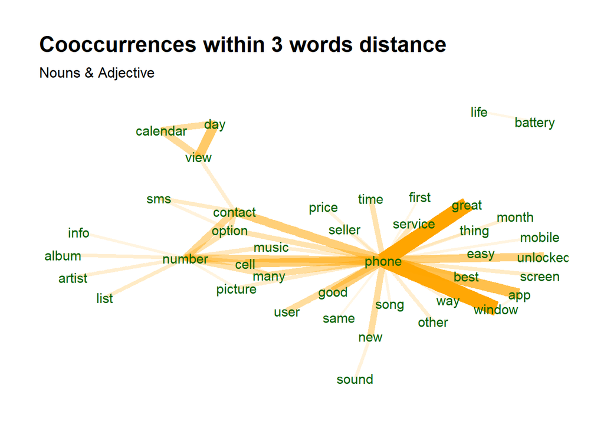

```r
# Visualising top-30 co-occurrences using a network plot
library(igraph)
library(ggraph)
library(ggplot2)

wordnetwork <- head(nokia_cooc, 50)
wordnetwork <- igraph::graph_from_data_frame(wordnetwork) # needs edgelist in first 2 colms.

ggraph(wordnetwork, layout = "fr") +

  geom_edge_link(aes(width = cooc, edge_alpha = cooc), edge_colour = "orange") +
  geom_node_text(aes(label = name), col = "darkgreen", size = 4) +

  theme_graph(base_family = "Arial Narrow") +
  theme(legend.position = "none") +

  labs(title = "Cooccurrences within 3 words distance", subtitle = "Nouns & Adjective")
```

Last but not least, here’s a nice example of using regex from session 1 to define phrase definitions and extract them from udpipe output.

Below, I use `as_phrasemachine()` to convert upos POSTags to simeple one-letter POSTags for easier manipulation in code, following this convention:

Phrases (A:adjective, C:coordinating conjuction, D:determiner, M:modifier of verb, N:noun, P:preposition). ‘O’ is ‘outside’ for punctuations etc.

```r
x$phrase_tag <- as_phrasemachine(x$upos, type = "upos")
  # x$phrase_tag[1:10];  x$upos[1:10];  x$token[1:10]   # uncomment & run to see what it does

# Building noun phrases thus (a adjective+noun, pre/postposition, optional determiner and another adjective+noun)
regexed_phrases <- keywords_phrases(x = x$phrase_tag,
                          term = x$token,
                          pattern = "(A|N)+N(P+D*(A|N)*N)*",
                          is_regex = TRUE,
                          ngram_max = 4,
                          detailed = FALSE)

head(subset(regexed_phrases, ngram > 2))
```

|  | keyword | ngram | freq |
| --- | --- | --- | --- |
| 21 | Lumia 920 which | 3 | 5 |
| 29 | my Nokia Lumia | 3 | 4 |
| 51 | unlocked GSM phone | 3 | 3 |
| 58 | calendar day view | 3 | 3 |
| 71 | best phone I | 3 | 2 |
| 72 | high end Android | 3 | 2 |

### UDPipe for other languages

Let’s try spanish, not lease because it has the same roman/latin alphabet and conveniently, has an inbuilt dataset in udpipe we can invoke directly.

```r
data(brussels_reviews)    # using inbuilt dataset in udpipe package
  # str(brussels_reviews);  head(brussels_reviews)

comments <- subset(brussels_reviews, language %in% "es")  # only for spanish comments

spanish_model = udpipe_load_model("./spanish-gsd-ud-2.4-190531.udpipe")

# system.time({
  x <- udpipe_annotate(spanish_model, x = comments$feedback[1:50])
  x <- as.data.frame(x)
# })  # 32.2 secs

#str(x)
head(x, 10)
```

|  | doc_id | paragraph_id | sentence_id | sentence | token_id | token | lemma | upos | xpos | feats | head_token_id | dep_rel | deps | misc |
| --- | --- | --- | --- | --- | --- | --- | --- | --- | --- | --- | --- | --- | --- | --- |
| 1 | doc1 | 1 | 1 | Gwen fue una magnifica anfitriona. | 1 | Gwen | Gwen | PROPN | NA | NA | 5 | nsubj | NA | NA |
| 2 | doc1 | 1 | 1 | Gwen fue una magnifica anfitriona. | 2 | fue | ser | AUX | NA | Mood=Ind\|Number=Sing\|Person=3\|Tense=Past\|VerbForm=Fin | 5 | cop | NA | NA |
| 3 | doc1 | 1 | 1 | Gwen fue una magnifica anfitriona. | 3 | una | uno | DET | NA | Definite=Ind\|Gender=Fem\|Number=Sing\|PronType=Art | 5 | det | NA | NA |
| 4 | doc1 | 1 | 1 | Gwen fue una magnifica anfitriona. | 4 | magnifica | magnificar | ADJ | NA | Gender=Fem\|Number=Sing | 5 | amod | NA | NA |
| 5 | doc1 | 1 | 1 | Gwen fue una magnifica anfitriona. | 5 | anfitriona | anfitriona | NOUN | NA | Gender=Fem\|Number=Sing | 0 | root | NA | SpaceAfter=No |
| 6 | doc1 | 1 | 1 | Gwen fue una magnifica anfitriona. | 6 | . | . | PUNCT | NA | NA | 5 | punct | NA | NA |
| 7 | doc1 | 1 | 2 | El motivo de mi viaje a Bruselas era la busqueda de un apartamento y Gwen me ayudo en todo momento tanto para las paginas en las que debia buscar como en las zonas que me aconsejaba. | 1 | El | el | DET | NA | Definite=Def\|Gender=Masc\|Number=Sing\|PronType=Art | 2 | det | NA | NA |
| 8 | doc1 | 1 | 2 | El motivo de mi viaje a Bruselas era la busqueda de un apartamento y Gwen me ayudo en todo momento tanto para las paginas en las que debia buscar como en las zonas que me aconsejaba. | 2 | motivo | motivo | NOUN | NA | Gender=Masc\|Number=Sing | 10 | nsubj | NA | NA |
| 9 | doc1 | 1 | 2 | El motivo de mi viaje a Bruselas era la busqueda de un apartamento y Gwen me ayudo en todo momento tanto para las paginas en las que debia buscar como en las zonas que me aconsejaba. | 3 | de | de | ADP | NA | NA | 5 | case | NA | NA |
| 10 | doc1 | 1 | 2 | El motivo de mi viaje a Bruselas era la busqueda de un apartamento y Gwen me ayudo en todo momento tanto para las paginas en las que debia buscar como en las zonas que me aconsejaba. | 4 | mi | mi | DET | NA | Number=Sing\|Person=1\|Poss=Yes\|PronType=Prs | 5 | det | NA | NA |

Neat, eh? Time now to move to desi languages.

### POSTagging Hindi text

I’m going to use Hindi text from Wikipedia’s Bharat page by ‘rvesting’ it, of course. Behold.

```r
require(stringr)
library(rvest)
url = 'https://hi.wikipedia.org/wiki/%E0%A4%AD%E0%A4%BE%E0%A4%B0%E0%A4%A4'

page = read_html(url)
nodes  = html_nodes(page,'p')
text = html_text(nodes)
text = text[text != '']

text  =  str_replace_all(text, "<.*?>", " ") # get rid of html junk
  # str(text)

hindi_model = udpipe_load_model("./hindi-hdtb-ud-2.4-190531.udpipe")

# system.time({
  x <- udpipe_annotate(hindi_model, x = text)
  x <- as.data.frame(x)
# })  # 9.2 secs

# str(x);
head(x, 10)   # UTF-8 encoding inside a DF doesn't display on R console. But it will for vectors.
```

|  | doc_id | paragraph_id | sentence_id | sentence | token_id | token | lemma | upos | xpos | feats | head_token_id | dep_rel | deps | misc |
| --- | --- | --- | --- | --- | --- | --- | --- | --- | --- | --- | --- | --- | --- | --- |
| 1 | doc1 | 1 | 1 | ( : , : Republic of India) | 1 |  |  | PROPN | NNP | Case=Nom\|Gender=Masc\|Number=Sing\|Person=3 | 23 | nsubj | NA | NA |
| 2 | doc1 | 1 | 1 | ( : , : Republic of India) | 2 | ( | ( | PUNCT | SYM | NA | 3 | punct | NA | SpaceAfter=No |
| 3 | doc1 | 1 | 1 | ( : , : Republic of India) | 3 |  |  | ADJ | JJ | NA | 5 | amod | NA | NA |
| 4 | doc1 | 1 | 1 | ( : , : Republic of India) | 4 | : | : | PUNCT | SYM | NA | 3 | punct | NA | NA |
| 5 | doc1 | 1 | 1 | ( : , : Republic of India) | 5 |  |  | PROPN | NNPC | Case=Nom\|Gender=Masc\|Number=Sing\|Person=3 | 12 | compound | NA | NA |
| 6 | doc1 | 1 | 1 | ( : , : Republic of India) | 6 |  |  | PROPN | NNP | Case=Nom\|Gender=Masc\|Number=Sing\|Person=3 | 12 | compound | NA | SpaceAfter=No |
| 7 | doc1 | 1 | 1 | ( : , : Republic of India) | 7 | , | COMMA | PUNCT | SYM | NA | 12 | punct | NA | NA |
| 8 | doc1 | 1 | 1 | ( : , : Republic of India) | 8 |  |  | PROPN | NNP | Case=Nom\|Gender=Masc\|Number=Sing\|Person=3 | 12 | compound | NA | SpaceAfter=No |
| 9 | doc1 | 1 | 1 | ( : , : Republic of India) | 9 | : | : | PUNCT | SYM | NA | 12 | punct | NA | NA |
| 10 | doc1 | 1 | 1 | ( : , : Republic of India) | 10 | Republic | Republic | PROPN | NNP | Case=Acc\|Gender=Masc\|Number=Sing\|Person=3 | 12 | compound | NA | NA |

To get the Hindi script to display on the R console, do the following (after much trial and error - if anybody has a better solution, lemme know asap).

```r
windowsFonts(devanew=windowsFont("Devanagari new normal"))
# However vector support devnagri scripts
head(x$token)    # Yay!
```

```
## [1] "भारत" "("        "आधिकारिक" "नाम:" "भारत" "गणराज्य"
```

And other things we did for the english wale models, all are now applicable here too. Ensoi…

```r
table(x$xpos)  # std penn treebank based POStags
```

```
##
##   CC  DEM INTF   JJ  JJC  NEG   NN  NNC  NNP NNPC  NST NSTC  PRP PRPC  PSP
##  301   50   40  649    6   12 1455  153  746  305  114    1  209    1 1370
##   QC  QCC   QF   QO   RB   RP  SYM VAUX   VM
##  296    8   75   32   27   98  865  320  590
```

```r
table(x$upos)  # UD based postags
```

```
##
##   ADJ   ADP   ADV   AUX CCONJ   DET  NOUN   NUM  PART  PRON PROPN PUNCT
##   687  1462    89   511   271   125  1609   304   110   210  1051   865
## SCONJ   SYM  VERB
##    30     2   399
```

```r
# So what're the most common nouns? verbs?
all_nouns = x %>% subset(., upos %in% "NOUN"); all_nouns$token[1:20]
```

```
##  [1] "उपमहाद्वीप" "देश" "रूप" "दृष्टि" "विश्व"
##  [6] "जनसंख्या" "दृष्टिकोण" "देश" "सीमा" "उत्तर"
## [11] "सीमा" "खाड़ी" "सिन्धु" "घाटी" "सभ्यता"
## [16] "व्यापार" "मार्गों" "साम्राज्यों" "विकास-स्थान" "उपमहाद्वीप"
```

```r
top_nouns = txt_freq(all_nouns$lemma)
head(top_nouns$key, 20)
```

```
##  [1] "देश" "राज्य" "सरकार" "वर्ष" "भाषा" "विश्व"
##  [7] "नाम" "चुनाव" "संविधान" "रूप" "दशक" "पार्टी"
## [13] "संबंध" "नेतृत्व" "स्वतन्त्रता" "समय" "हिन्दी" "नदी"
## [19] "क्षेत्र" "सदस्य"
```

```r
all_verbs = x %>% subset(., upos %in% "VERB")
top_verbs = txt_freq(all_verbs$lemma)
head(top_verbs$key, 20)
```

```
##  [1] "कर" "हो" "बन" "रह" "बना" "दे" "मिल" "आ" "निभा" "मान"
## [11] "कह" "चल" "अपना" "है" "पा" "सौंप" "रख" "जीत" "उभर" "पहुँच"
```

Last but not least, let’s do one final display aid for Hindi.

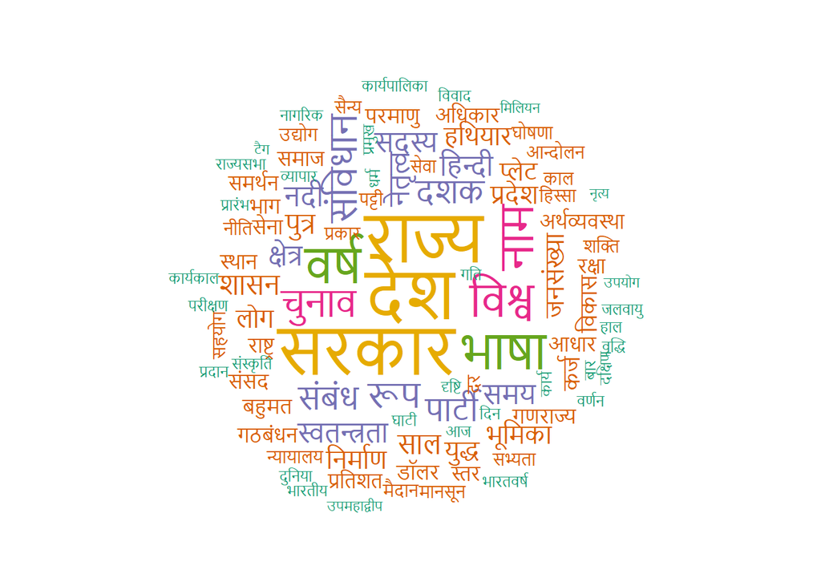

```r
library(wordcloud)
wordcloud(words = top_nouns$key,
          freq = top_nouns$freq,
          min.freq = 2,
          max.words = 100,
          random.order = FALSE,
          colors = brewer.pal(6, "Dark2"))
```

OK, dassit for now. Questions? Comments?

Sudhir